# A Gibbs Sampler for Binary-predictor Poisson Regression

## Model

The model follows a simple Poisson regression setup. To be specific,

$y_i\sim\mbox{Poisson}\bigg(\exp\big\{ x_{i}^{\top}\beta \big\}\bigg)$, for $i=1,\ldots,n$.

Bayesian inference on the regression coefficients $\beta\in\Re^{p}$ is usually intractable and hence needs to be done via MCMC. And usually Metropolis Hasting type algorithm has to be done except when the predictors $x_{i}\in\{0,1\}^{p}$ are binary vectors. In this case a simpler Gibbs sampler can be implemented. Now let's focus on this special case and derive this Gibbs sampler by scratch.

First we need to do a change of variable. Letting $\lambda_{j}=\exp\{\beta_{j}\}$ we will have a following equivalent model:

$y_i\sim\mbox{Poisson}\bigg(\prod_{j=1}^{p}\lambda_{j}^{x_{ij}}\bigg)$, for $i=1,\ldots,n$.

I put Jeffrey priors on these $\lambda$'s:

$\pi(\lambda_{j})\propto\lambda_{j}^{1/2-1}$.

## Gibbs Sampler

I provide the derivation of the conditional posterior distribution as follows:

$p(\lambda_{j}|\lambda_{/j},D)$

$\propto L(D;\lambda_{1},\ldots,\lambda_{p})\pi(\lambda_{j})$

$=\prod_{i=1}^{n}\bigg(\dfrac{\prod_{k=1}^{p}\lambda_{k}^{y_{i}x_{ik}}}{y_{i}!}\exp\big\{-\prod_{k=1}^{p}\lambda_{k}^{x_{ik}}\big\}\bigg)\lambda_{j}^{1/2-1}$

$\propto \lambda_{j}^{\sum_{i=1}^{n}y_{i}x_{ij}+1/2-1}\exp\big\{ -\lambda_{j}\sum_{i=1}^{n}x_{ij}\prod_{k\neq j}\lambda_{k}^{x_{ik}} \big\}.$

Hence we have $\lambda_{j}|\lambda_{/j},D \sim \mbox{Gamma}\big(\sum_{i=1}^{n}y_{i}x_{ij}+1/2,\sum_{i=1}^{n}x_{ij}\prod_{k\neq j}\lambda_{k}^{x_{ik}}\big)$.

The Gibbs sampling algorithm is summarized as follows:

At iteration $t$, for $j=1,\ldots,p$, sample $\lambda^{(t)}_{j}$ from $p(\lambda_{j}|\lambda^{(t)}_{1},\ldots,\lambda^{(t)}_{j-1},\lambda^{(t-1)}_{j+1},\ldots,\lambda^{(t-1)}_{p},D)$.

## Python Code

I implemented the above Gibbs sampling algorithm in Python.

```python
import numpy as np
from operator import mul

def poissregGibbs(y,x,nb,ns):
    """ Gibbs sampler for binary-predictor Poisson regression

        Args:
            y: np.array, responses
            x: np.array, predictors
            nb: int, number of burn-ins
            ns: int, number of after-burnin samples
    """
    n,p = x.shape
    # initial values for lmbda
    lmbda = np.array( [1.0 for __ in range(p)] )
    # sufficient statistics
    prodLambda = np.array( [1.0 for __ in range(n)] )
    sxy = [np.inner(y,x[:,j]) for j in range(p)]
    # store sampled values
    ret = [[0 for __ in range(ns)] for __ in range(p)]
    for it in range(nb+ns):
        if not (it+1) % ((nb+ns)/10):
            print it
        for j in range(p):
            prodLambda[x[:,j]==1] = prodLambda[x[:,j]==1]/lmbda[j]
            rate = np.sum(prodLambda[x[:,j]==1])
            lmbda[j] = np.random.gamma( sxy[j]+.5, 1.0/rate )
            prodLambda[x[:,j]==1] = prodLambda[x[:,j]==1]*lmbda[j]
        if it >= nb:
            for j in range(p):
                ret[j][it-nb] = lmbda[j]
    return ret
```

## Simulation Study

I did the following simulation study where the underlying truth is $\lambda_1=0.1$, $\lambda_2=1$, $\lambda_3=4$ and the sample size $n=1000$.

```python
n,lmbda = 1000,[0.1,1,4]
x = np.array( [np.random.binomial(1,0.5,3) for __ in range(n)] )
pmean = [reduce(mul, [lmbda[k] if x[i][k] else 1 for k in range(3)], 1) for i in range(n)]
y = [np.random.poisson(pmean[i]) for i in range(n)]
```

```python
res = poissregGibbs(y,x,5000,5000)
```

```
999
1999
2999
3999
4999
5999
6999
7999
8999
9999
```

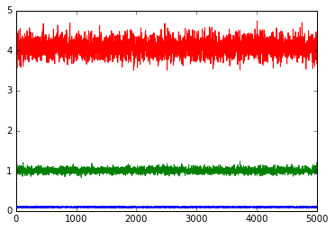

```python
%matplotlib inline
import matplotlib.pyplot as plt

plt.plot(range(5000), res[0])
plt.plot(range(5000), res[1])
plt.plot(range(5000), res[2])
plt.show()
```

As can be seen, the algorithm did correct inference on the values of $\lambda$'s.

## Computation Test

How well does this Gibbs sampler handles large dataset? I did the following simulation study where I let $p=45$ and $n=30000$. I recorded the computation time for collecting 1000 samples.

```python
n,p,lmbda = 30000,45,np.random.gamma(1.1,1,45)
x = np.array( [np.random.binomial(1,0.5,p) for __ in range(n)] )
pmean = [reduce(mul, [lmbda[k] if x[i][k] else 1 for k in range(p)], 1) for i in range(n)]
y = [np.random.poisson(pmean[i]) for i in range(n)]
```

```python
import timeit
start = timeit.default_timer()
res = poissregGibbs(y,x,500,500)
stop = timeit.default_timer()
print stop - start
```

```
99
199
299
399
499
599
699
799
899
999
79.0372290611
```

```python
79.0372290611*15000/1000/60
```

```
19.759307265275005
```

The sampler ran for **79 seconds**. Suppose one wants to collect 15000 samples then the sampler should roughly run **19 minutes** based on simple multiplying 79 seconds with 15. Now let us take a closer look at the computational cost of the sampler for each iteratation.

As can be clearly seen, in sampling $\lambda_j$'s from $\mbox{Gamma}\big(\sum_{i=1}^{n}y_{i}x_{ij}+1/2,\sum_{i=1}^{n}x_{ij}\prod_{k\neq j}\lambda_{k}^{x_{ik}}\big)$, the dominant computation is computing $\sum_{i=1}^{n}x_{ij}\prod_{k\neq j}\lambda_{k}^{x_{ik}}$. Computing $\sum_{i=1}^{n}y_{i}x_{ij}$ requires only a single pass before the iteration and need not be updated within the iteration.

The cost of computing $\sum_{i=1}^{n}x_{ij}\prod_{k\neq j}\lambda_{k}^{x_{ik}}$ seems to be $O(np)$ at a first glance but it is actually $O(n)$ since only one of the $\lambda_k$'s is changed at each time. Hence the overall computational cost of a single iteration of the derived Gibbs sampler is $O(np)$.